# Tutorial para usar y crear paletas y personalizar temas de gráficos en ggplot

15-12-2021

## Cargar librerías

El primer paso es cargar las siguientes librerías que nos permitirán dar formato a los gráficos:

```r
library(tidyverse)
library(palmerpenguins)
library(chilemapas)
library(paletteer)
library(tidyverse)
library(gt)
library(kableExtra)
library(flextable)
library(ggplot2)
library(ggrepel)
library(gcookbook)
library(scales)
library(lubridate)
library(DT)
library(leaflet)
library(xaringan)
library(xaringanExtra)
```

## Creación de gráficos

Vamos a usar la base de datos `penguins` del paquete `palmerpenguins` para crear nuestros primeros gráficos tipo, a los cuales le vamos a ir personalizando el formato más adelante.

Primero vamos a explorar nuestras variables. Para eso debemos escribir `penguins` en la consola y apretamos enter.

## Gráficos de barras

A continuación vamos a crear un gráfico de barras horizontales a través de la función `geom_bar` de `ggplot`, la cual permite hacer un recuento de casos por la variable que seleccionemos y además grafica.

Crearemos nuestro gráfico que se llamará **barras1**. En este caso la variable **y** vaa ser `island` y **x** será el conteo de la variable `species`. Las barras serán coloreadas según las categorías de la variable especie, esto lo determinamos con la función `fill` .

## Gráficos de barras

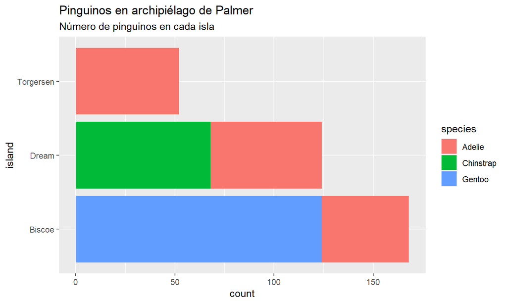

## Gráficos de puntos

Ahora vamos a crear un gráfico de puntos a través de la función `geom_point` de `ggplot`.

## Gráficos de puntos

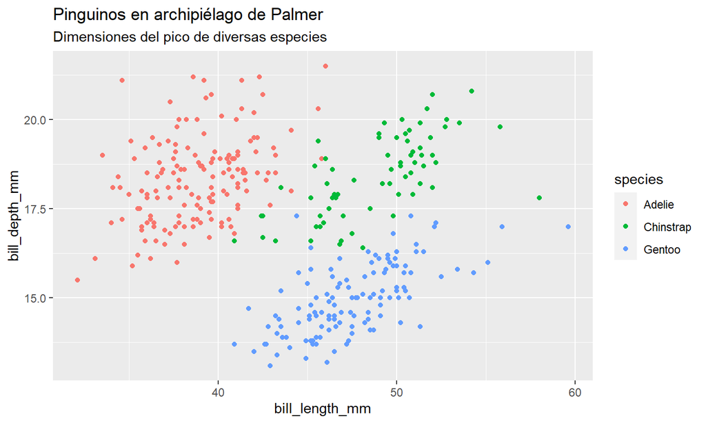

## ¿Cómo crear nuestra propia paleta?

Para usar o crear paletas de colores debemos trabajar con el paquete `paletteer.` Las paletas de colores pueden ser de 2 tipos; discretas y continuas. Las discretas son para cuando necesitamos determinado número de colores y las continuas permiten hacer transiciones de colores.

Hay una amplia variedad de paletas de colores, por lo que en la siguiente [página](https://emilhvitfeldt.github.io/r-color-palettes/discrete.html) pueden encontrar algunos ejemplos de paletas discretas que les puedan servir de inspiración para elaborar sus propias paletas.

## ¿Cómo crear nuestra propia paleta?

A continuación vamos a explorar la paleta `awtools::ppalette` para ver los códigos de los colores que la componen.

```
## <colors>
## #F7DC05FF #3D98D3FF #EC0B88FF #5E35B1FF #F9791EFF #3DD378FF #C6C6C6FF #444444FF
```

Para utilizar los colores que nos gustaron de esta paleta crearemos un vector que se llamará `col_d_1`en el cual vamos a agupar los colores de `awtools::ppalette`.

## ¿Cómo utilizamos nuestra paleta?

Ahora que hemos creado el vector **col_d_1** podemos utilizar sus colores para rellenar los gráficos **barras1 puntos1** que creamos anteriormente. Para esto debemos utilizar la función **scale_fill_manual** para el gráfico de barras y **scale_color_manual** para los gráficos de puntos.

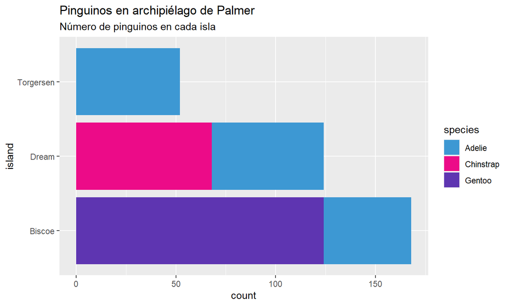

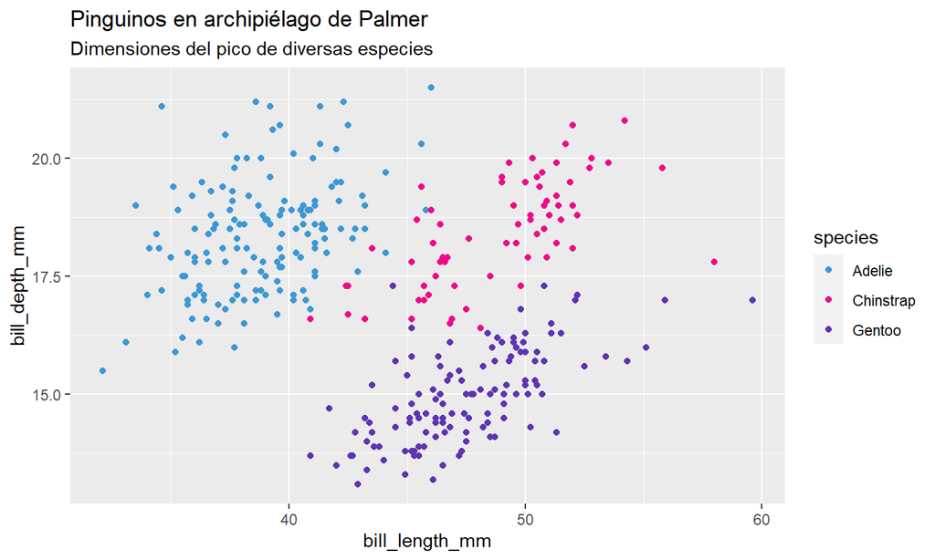

## ¿Cómo utilizamos nuestra paleta?

Otra forma más rápida para utilizar estos mismos colores más adelante es crear un objeto al cual le podemos asignar un nombre que nos haga sentido o que represente una paleta institucional por ejemplo. De esta forma creamos el objeto `mi_fill_1` para utilizar en los gráficos de barras y otro objeto que se llame `mi_color_1` para los gráficos de puntos.

Ahora le daremos formato a los gráficos `barras1` y `puntos1` solo agregando el nombre de ambos objetos que contienen la paleta de colores con las que colorearemos las figuras.

## ¿Cómo utilizamos nuestra paleta?

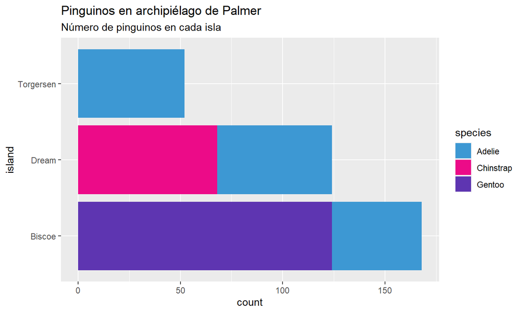

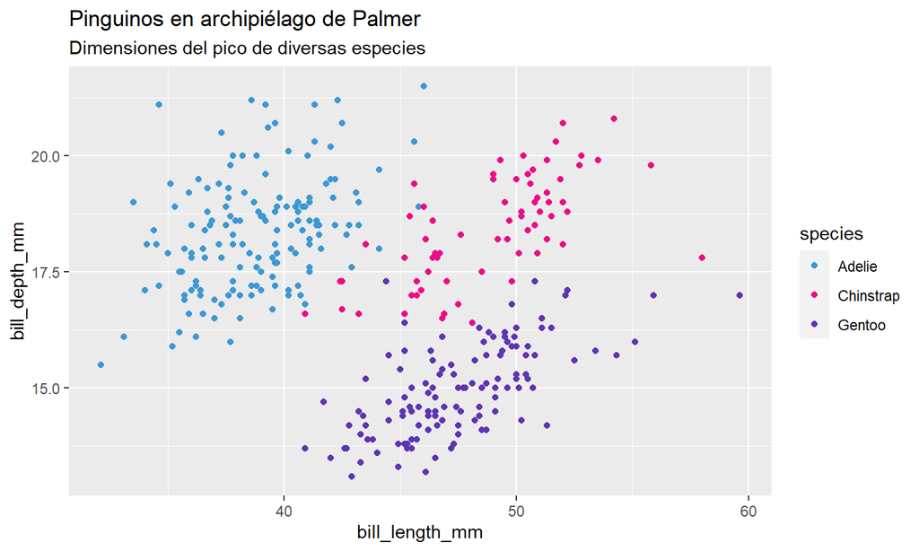

## ¿Cómo ajustar el formato o tema de los gráficos?

A través del comando `theme` podemos ir ajustando el formato de nuestros gráficos tales como; tamaño de la letra, líneas de la cuadrícula, color del fondo, entre otros.

A continuación tomaremos los gráficos `barras1` y `puntos1` y modificaremos el tamaño de la letra del título con el comando `plot.title` y del subtítulo con el comando `plot.subtitle` y dentro de esos argumentos también podemos modificar el color del texto con el comando `color`. Para ver los nombres de los colores disponibles podemos escribir `colors` en la consola.

## ¿Cómo ajustar el formato o tema de los gráficos?

Gráfico de barra

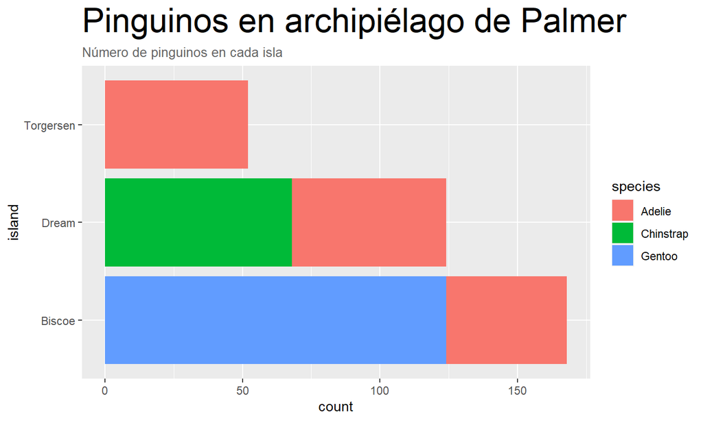

Gráfico de puntos

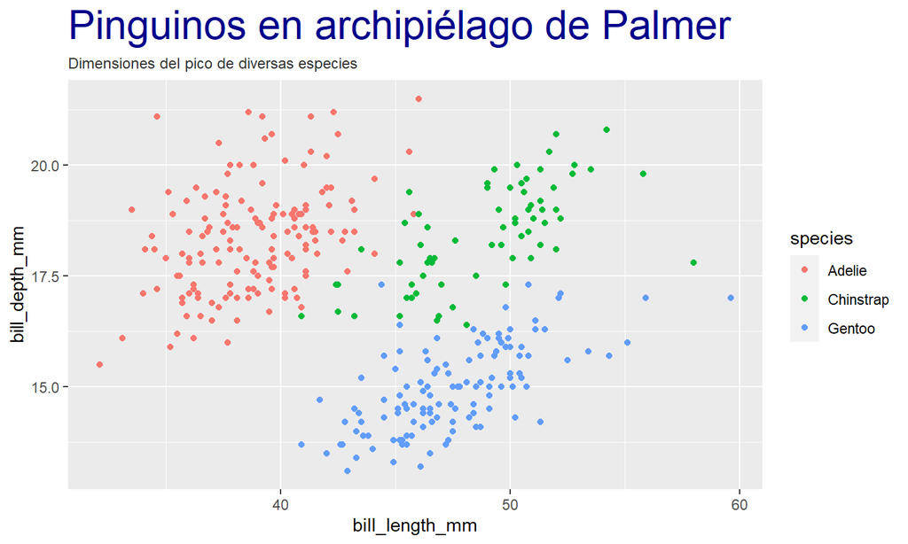

## Creando nuestro propio tema

Ahora crearemos nuestro propio tema con los ajustes que nos gusten y los guardaremos como un objeto que se llame `mi_tema` al cual vamos a poder llamar para asignar ese formato a nuestros gráficos y así personalizarlos. Con el comando `panel.grid.major` definimos el formato de la cuadrícula, con `panel.grid.minor` los ejes y con `panel.background`el fondo del gráfico.

## Creando nuestro propio tema

Ahora que hemos personalizado nuestra paleta de colores y hemos creado nuestro tema, vamos a darle formato nuevamente a los gráficos `barras1` y `puntos1` utilizando los objetos que hemos creado anteriomente.

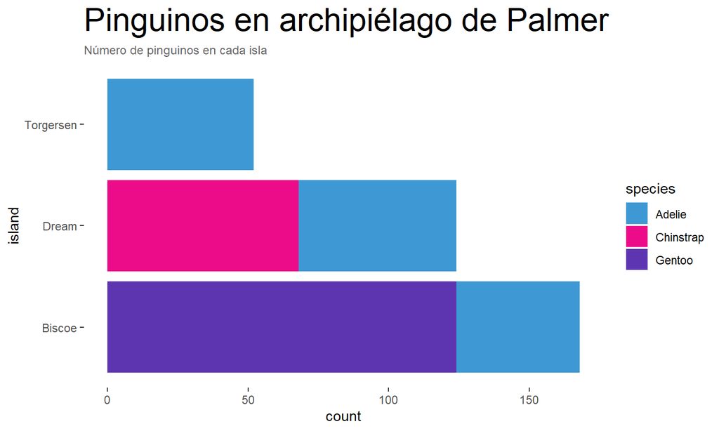